# WS05

Note:

Question 1-5 are answered in this notebook along with the code and the development of the notebook.

Report in the other PDF file covers these topics as requested:

- Discuss the results (your understanding) of the clustering algorithm on clustering crime dataset used in this work (Max 500 words).
- Change the number of clusters to a different value and perform the clustering algorithm and draw the graph again. Discuss your results briefly.
- Consider a different towns (example : dudley) and perform the clustering again. You should choose the number of clusters from the dendrogram according. Discuss your results briefly.

```python
import pandas as pd
import matplotlib.pyplot as plt
import folium
import os, re
from sklearn.preprocessing import StandardScaler
from sklearn.preprocessing import normalize
from IPython.display import IFrame
from sklearn.cluster import AgglomerativeClustering
import scipy.cluster.hierarchy as shc
%matplotlib inline
import warnings
warnings.filterwarnings('ignore')
```

```python
path_to_data = './crime'
cd = os.path.dirname(os.path.abspath(path_to_data))

i = 0
columns = range(1,100)
dfList = []

for root, dirs, files in os.walk(cd):
    for fname in files:
        if re.match("^.*.csv$", fname):
            frame = pd.read_csv(os.path.join(root, fname))
            frame['key'] = "file{}".format(i)
            dfList.append(frame)
            i += 1

dataset = pd.concat(dfList)
```

```python
dataset.head()
```

|  | Crime ID | Month | Reported by | Falls within | Longitude | Latitude | Location | LSOA code | LSOA name | Crime type | Last outcome category | Context | key |
| --- | --- | --- | --- | --- | --- | --- | --- | --- | --- | --- | --- | --- | --- |
| 0 | cb47df2e6dbe1b37b6362a9312116911e0542f31dbdd56... | 2022-11 | West Midlands Police | West Midlands Police | -1.848972 | 52.588428 | On or near Woodside | E01009417 | Birmingham 001A | Other theft | Unable to prosecute suspect | NaN | file0 |
| 1 | 47d811512341fd0ecec13cb254b40f1b220928a31d349a... | 2022-11 | West Midlands Police | West Midlands Police | -1.849790 | 52.590937 | On or near Walsall Road | E01009417 | Birmingham 001A | Violence and sexual offences | Investigation complete; no suspect identified | NaN | file0 |
| 2 | da2ff35b910f6ec63d2f4f6c006fa46991675511a2f25d... | 2022-11 | West Midlands Police | West Midlands Police | -1.844834 | 52.590077 | On or near Heathfield Road | E01009417 | Birmingham 001A | Violence and sexual offences | Unable to prosecute suspect | NaN | file0 |
| 3 | 08fe094d4f9b3df0a748b8605c92e58c7cc6ebf171bdc3... | 2022-11 | West Midlands Police | West Midlands Police | -1.849790 | 52.590937 | On or near Walsall Road | E01009417 | Birmingham 001A | Violence and sexual offences | Unable to prosecute suspect | NaN | file0 |
| 4 | a8aa5abff380c85b94e97fd746ed67f4b02d21716a00da... | 2022-11 | West Midlands Police | West Midlands Police | -1.847123 | 52.593864 | On or near Bramble Way | E01009417 | Birmingham 001A | Violence and sexual offences | Unable to prosecute suspect | NaN | file0 |

```python
print(dataset.shape)
```

```
(1253892, 13)
```

```python
name_number = 'RianYan-2424072'
dataset.to_csv(name_number, index=False)
```

```python
data = pd.read_csv(name_number)
```

```python
data['Crime type'].value_counts()
```

```
Crime type
Violence and sexual offences    527940
Vehicle crime                   125466
Public order                    107829
Criminal damage and arson        95256
Other theft                      85566
Burglary                         68814
Anti-social behaviour            64362
Shoplifting                      57903
Robbery                          27603
Drugs                            26025
Possession of weapons            23727
Other crime                      20934
Theft from the person            14625
Bicycle theft                     7842
Name: count, dtype: int64
```

Q1: Using a similar approach display the number of crimes in each month. You can use the "Month" column to do that.

```python
data['Month'].value_counts()
```

```
Month
2022-07    103746
2022-05    102315
2022-08    101025
2022-06    100002
2022-10     98874
2022-03     97791
2023-03     97356
2022-04     95529
2022-09     95091
2022-11     92892
2023-01     92811
2023-02     88431
2022-12     88029
Name: count, dtype: int64
```

```python
data['town'] = data['LSOA name'].str.split(' ').str[0]
```

```python
data.head()
```

|  | Crime ID | Month | Reported by | Falls within | Longitude | Latitude | Location | LSOA code | LSOA name | Crime type | Last outcome category | Context | key | town |
| --- | --- | --- | --- | --- | --- | --- | --- | --- | --- | --- | --- | --- | --- | --- |
| 0 | cb47df2e6dbe1b37b6362a9312116911e0542f31dbdd56... | 2022-11 | West Midlands Police | West Midlands Police | -1.848972 | 52.588428 | On or near Woodside | E01009417 | Birmingham 001A | Other theft | Unable to prosecute suspect | NaN | file0 | Birmingham |
| 1 | 47d811512341fd0ecec13cb254b40f1b220928a31d349a... | 2022-11 | West Midlands Police | West Midlands Police | -1.849790 | 52.590937 | On or near Walsall Road | E01009417 | Birmingham 001A | Violence and sexual offences | Investigation complete; no suspect identified | NaN | file0 | Birmingham |
| 2 | da2ff35b910f6ec63d2f4f6c006fa46991675511a2f25d... | 2022-11 | West Midlands Police | West Midlands Police | -1.844834 | 52.590077 | On or near Heathfield Road | E01009417 | Birmingham 001A | Violence and sexual offences | Unable to prosecute suspect | NaN | file0 | Birmingham |
| 3 | 08fe094d4f9b3df0a748b8605c92e58c7cc6ebf171bdc3... | 2022-11 | West Midlands Police | West Midlands Police | -1.849790 | 52.590937 | On or near Walsall Road | E01009417 | Birmingham 001A | Violence and sexual offences | Unable to prosecute suspect | NaN | file0 | Birmingham |
| 4 | a8aa5abff380c85b94e97fd746ed67f4b02d21716a00da... | 2022-11 | West Midlands Police | West Midlands Police | -1.847123 | 52.593864 | On or near Bramble Way | E01009417 | Birmingham 001A | Violence and sexual offences | Unable to prosecute suspect | NaN | file0 | Birmingham |

```python
towns = ['Wolverhampton']
filtered_data = data[data.town.str.contains('|'.join(towns), na=False)]
filtered_data.head()
```

|  | Crime ID | Month | Reported by | Falls within | Longitude | Latitude | Location | LSOA code | LSOA name | Crime type | Last outcome category | Context | key | town |
| --- | --- | --- | --- | --- | --- | --- | --- | --- | --- | --- | --- | --- | --- | --- |
| 28063 | 3740d3b5932e40edd0b2d94ba63bfc787d237ef876374b... | 2022-11 | West Midlands Police | West Midlands Police | -2.129332 | 52.618605 | On or near Barrington Close | E01010434 | Wolverhampton 001A | Burglary | Investigation complete; no suspect identified | NaN | file0 | Wolverhampton |
| 28064 | 861910c2c962166de706c516ec55038a0ab9c46f6a14d6... | 2022-11 | West Midlands Police | West Midlands Police | -2.121103 | 52.617840 | On or near Sherborne Road | E01010434 | Wolverhampton 001A | Burglary | Unable to prosecute suspect | NaN | file0 | Wolverhampton |
| 28065 | bb82e4a2a6ca33c8b527b2270c8716793789d63769f010... | 2022-11 | West Midlands Police | West Midlands Police | -2.129332 | 52.618605 | On or near Barrington Close | E01010434 | Wolverhampton 001A | Burglary | Investigation complete; no suspect identified | NaN | file0 | Wolverhampton |
| 28066 | 7be5d72cf3e24376607e6b0478fdcca8a4cf07653a308c... | 2022-11 | West Midlands Police | West Midlands Police | -2.126509 | 52.617745 | On or near Marklin Avenue | E01010434 | Wolverhampton 001A | Burglary | Investigation complete; no suspect identified | NaN | file0 | Wolverhampton |
| 28067 | e4c839a07f0475a1dae66ce5710e0a7591ef9b39491bf1... | 2022-11 | West Midlands Police | West Midlands Police | -2.129332 | 52.618605 | On or near Barrington Close | E01010434 | Wolverhampton 001A | Criminal damage and arson | Investigation complete; no suspect identified | NaN | file0 | Wolverhampton |

Q2: Display crime types in Wolverhampton.

```python
filtered_data['Crime type'].value_counts()
```

```
Crime type
Violence and sexual offences    54645
Public order                    10959
Vehicle crime                    9564
Criminal damage and arson        9327
Other theft                      7389
Burglary                         6282
Shoplifting                      6138
Anti-social behaviour            5436
Other crime                      2319
Drugs                            2181
Robbery                          2139
Possession of weapons            2106
Theft from the person             972
Bicycle theft                     885
Name: count, dtype: int64
```

```python
filtered_data['LSOA code'].value_counts().nlargest(10)
```

```
LSOA code
E01010521    11172
E01010564     3849
E01010414     2601
E01010530     2370
E01010450     1998
E01010410     1950
E01010476     1761
E01010472     1710
E01010473     1674
E01010508     1596
Name: count, dtype: int64
```

Q3: Provide a prime landmark of alteast 2 LSOA code.If there is no recognisable prime landmark, provide name(s) of the nearby streets/roads sorrounding that area.

E01010521 - Univeristy of Wolverhampton

E01010414 - The Street names surrounding this area are: Wellington Rd., Black Country Route, and Oxford St.

```python
filtered_important_data = filtered_data[['LSOA code','Crime type']]
```

```python
filtered_important_data.head()
```

|  | LSOA code | Crime type |
| --- | --- | --- |
| 28063 | E01010434 | Burglary |
| 28064 | E01010434 | Burglary |
| 28065 | E01010434 | Burglary |
| 28066 | E01010434 | Burglary |
| 28067 | E01010434 | Criminal damage and arson |

```python
filtered_important_data = filtered_data[['LSOA code','Crime type']]
filtered_important_data = pd.get_dummies(filtered_important_data, columns=['Crime type'])
clustering_data = filtered_important_data.groupby(['LSOA code']).agg({'Crime type_Anti-social behaviour':'sum',
'Crime type_Bicycle theft':'sum',
'Crime type_Burglary':'sum',
'Crime type_Criminal damage and arson':'sum',
'Crime type_Drugs':'sum',
'Crime type_Other crime':'sum',
'Crime type_Other theft':'sum',
'Crime type_Possession of weapons':'sum',
'Crime type_Public order':'sum',
'Crime type_Robbery':'sum',
'Crime type_Shoplifting':'sum',
'Crime type_Theft from the person':'sum',
'Crime type_Vehicle crime':'sum',
'Crime type_Violence and sexual offences':'sum'}).reset_index()
```

```python
clustering_data[:5]
```

|  | LSOA code | Crime type_Anti-social behaviour | Crime type_Bicycle theft | Crime type_Burglary | Crime type_Criminal damage and arson | Crime type_Drugs | Crime type_Other crime | Crime type_Other theft | Crime type_Possession of weapons | Crime type_Public order | Crime type_Robbery | Crime type_Shoplifting | Crime type_Theft from the person | Crime type_Vehicle crime | Crime type_Violence and sexual offences |
| --- | --- | --- | --- | --- | --- | --- | --- | --- | --- | --- | --- | --- | --- | --- | --- |
| 0 | E01010410 | 108 | 18 | 84 | 129 | 9 | 30 | 459 | 42 | 183 | 27 | 105 | 15 | 177 | 564 |
| 1 | E01010411 | 18 | 3 | 18 | 69 | 3 | 9 | 21 | 0 | 45 | 6 | 3 | 0 | 42 | 264 |
| 2 | E01010412 | 36 | 0 | 30 | 96 | 12 | 36 | 27 | 15 | 96 | 21 | 18 | 3 | 69 | 453 |
| 3 | E01010413 | 21 | 9 | 21 | 93 | 9 | 21 | 36 | 9 | 78 | 12 | 33 | 0 | 66 | 342 |
| 4 | E01010414 | 120 | 36 | 147 | 255 | 24 | 39 | 120 | 48 | 213 | 48 | 285 | 72 | 243 | 951 |

```python
clustering_data_original = clustering_data.copy()
```

```python
clustering_data_original.head()
```

|  | LSOA code | Crime type_Anti-social behaviour | Crime type_Bicycle theft | Crime type_Burglary | Crime type_Criminal damage and arson | Crime type_Drugs | Crime type_Other crime | Crime type_Other theft | Crime type_Possession of weapons | Crime type_Public order | Crime type_Robbery | Crime type_Shoplifting | Crime type_Theft from the person | Crime type_Vehicle crime | Crime type_Violence and sexual offences |
| --- | --- | --- | --- | --- | --- | --- | --- | --- | --- | --- | --- | --- | --- | --- | --- |
| 0 | E01010410 | 108 | 18 | 84 | 129 | 9 | 30 | 459 | 42 | 183 | 27 | 105 | 15 | 177 | 564 |
| 1 | E01010411 | 18 | 3 | 18 | 69 | 3 | 9 | 21 | 0 | 45 | 6 | 3 | 0 | 42 | 264 |
| 2 | E01010412 | 36 | 0 | 30 | 96 | 12 | 36 | 27 | 15 | 96 | 21 | 18 | 3 | 69 | 453 |
| 3 | E01010413 | 21 | 9 | 21 | 93 | 9 | 21 | 36 | 9 | 78 | 12 | 33 | 0 | 66 | 342 |
| 4 | E01010414 | 120 | 36 | 147 | 255 | 24 | 39 | 120 | 48 | 213 | 48 | 285 | 72 | 243 | 951 |

```python
clustering_data.drop(['LSOA code'], axis = 1, inplace = True, errors = 'ignore')
```

```python
clustering_data.head()
```

|  | Crime type_Anti-social behaviour | Crime type_Bicycle theft | Crime type_Burglary | Crime type_Criminal damage and arson | Crime type_Drugs | Crime type_Other crime | Crime type_Other theft | Crime type_Possession of weapons | Crime type_Public order | Crime type_Robbery | Crime type_Shoplifting | Crime type_Theft from the person | Crime type_Vehicle crime | Crime type_Violence and sexual offences |
| --- | --- | --- | --- | --- | --- | --- | --- | --- | --- | --- | --- | --- | --- | --- |
| 0 | 108 | 18 | 84 | 129 | 9 | 30 | 459 | 42 | 183 | 27 | 105 | 15 | 177 | 564 |
| 1 | 18 | 3 | 18 | 69 | 3 | 9 | 21 | 0 | 45 | 6 | 3 | 0 | 42 | 264 |
| 2 | 36 | 0 | 30 | 96 | 12 | 36 | 27 | 15 | 96 | 21 | 18 | 3 | 69 | 453 |
| 3 | 21 | 9 | 21 | 93 | 9 | 21 | 36 | 9 | 78 | 12 | 33 | 0 | 66 | 342 |
| 4 | 120 | 36 | 147 | 255 | 24 | 39 | 120 | 48 | 213 | 48 | 285 | 72 | 243 | 951 |

```python
data_scaled = normalize(clustering_data)
data_scaled = pd.DataFrame(data_scaled, columns=clustering_data.columns)
```

```python
data_scaled.head()
```

|  | Crime type_Anti-social behaviour | Crime type_Bicycle theft | Crime type_Burglary | Crime type_Criminal damage and arson | Crime type_Drugs | Crime type_Other crime | Crime type_Other theft | Crime type_Possession of weapons | Crime type_Public order | Crime type_Robbery | Crime type_Shoplifting | Crime type_Theft from the person | Crime type_Vehicle crime | Crime type_Violence and sexual offences |
| --- | --- | --- | --- | --- | --- | --- | --- | --- | --- | --- | --- | --- | --- | --- |
| 0 | 0.134580 | 0.022430 | 0.104673 | 0.160748 | 0.011215 | 0.037383 | 0.571964 | 0.052337 | 0.228038 | 0.033645 | 0.130841 | 0.018692 | 0.220561 | 0.702805 |
| 1 | 0.063848 | 0.010641 | 0.063848 | 0.244750 | 0.010641 | 0.031924 | 0.074489 | 0.000000 | 0.159620 | 0.021283 | 0.010641 | 0.000000 | 0.148978 | 0.936435 |
| 2 | 0.074458 | 0.000000 | 0.062048 | 0.198555 | 0.024819 | 0.074458 | 0.055844 | 0.031024 | 0.198555 | 0.043434 | 0.037229 | 0.006205 | 0.142711 | 0.936931 |
| 3 | 0.056095 | 0.024041 | 0.056095 | 0.248422 | 0.024041 | 0.056095 | 0.096163 | 0.024041 | 0.208354 | 0.032054 | 0.088150 | 0.000000 | 0.176299 | 0.913551 |
| 4 | 0.108702 | 0.032611 | 0.133161 | 0.230993 | 0.021740 | 0.035328 | 0.108702 | 0.043481 | 0.192947 | 0.043481 | 0.258168 | 0.065221 | 0.220123 | 0.861467 |

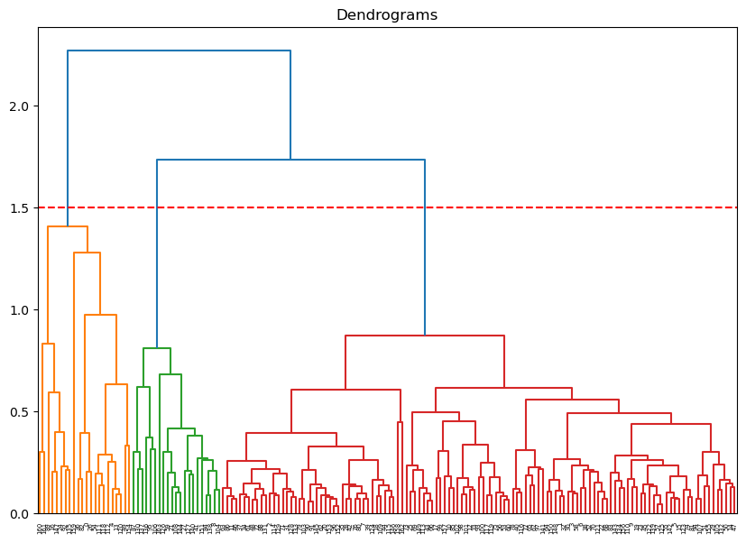

```python
plt.figure(figsize=(10, 7))
plt.title("Dendrograms")
dend = shc.dendrogram(shc.linkage(data_scaled, method='ward'))
plt.axhline(y=1.5, color='r', linestyle='--')
```

Q4. Discuss what happens when you decide to cut the dendogram in different level.

Imagine we cut the dendrogram in a different level at 2.0, it will only show 2 clusters.

```python
cluster = AgglomerativeClustering(n_clusters=3, affinity='euclidean', linkage='ward')
cluster_ids = cluster.fit_predict(data_scaled)
```

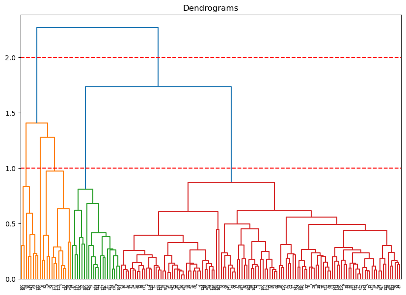

```python
plt.figure(figsize=(10, 7))
plt.title("Dendrograms")
dend = shc.dendrogram(shc.linkage(data_scaled, method='ward'))
plt.axhline(y=2.0, color='r', linestyle='--')
plt.axhline(y=1.0, color='r', linestyle='--')
```

Imagine we cut the dendrograms at level 1.0, it will show 5 clusters.

In sum, cutting a dendrogram at higher levels yields fewer, larger clusters with coarser groupings, combining more diverse data points. Cutting at lower levels results in more, smaller clusters with finer groupings, capturing more specific relationships among similar data points. This affects the granularity and specificity of the clustering outcome.

```python
clustering_data['cluster'] = cluster_ids
clustering_data.head()
```

|  | Crime type_Anti-social behaviour | Crime type_Bicycle theft | Crime type_Burglary | Crime type_Criminal damage and arson | Crime type_Drugs | Crime type_Other crime | Crime type_Other theft | Crime type_Possession of weapons | Crime type_Public order | Crime type_Robbery | Crime type_Shoplifting | Crime type_Theft from the person | Crime type_Vehicle crime | Crime type_Violence and sexual offences | cluster |
| --- | --- | --- | --- | --- | --- | --- | --- | --- | --- | --- | --- | --- | --- | --- | --- |
| 0 | 108 | 18 | 84 | 129 | 9 | 30 | 459 | 42 | 183 | 27 | 105 | 15 | 177 | 564 | 0 |
| 1 | 18 | 3 | 18 | 69 | 3 | 9 | 21 | 0 | 45 | 6 | 3 | 0 | 42 | 264 | 1 |
| 2 | 36 | 0 | 30 | 96 | 12 | 36 | 27 | 15 | 96 | 21 | 18 | 3 | 69 | 453 | 1 |
| 3 | 21 | 9 | 21 | 93 | 9 | 21 | 36 | 9 | 78 | 12 | 33 | 0 | 66 | 342 | 1 |
| 4 | 120 | 36 | 147 | 255 | 24 | 39 | 120 | 48 | 213 | 48 | 285 | 72 | 243 | 951 | 0 |

```python
hiarchical_cluster = pd.DataFrame(round(clustering_data.groupby('cluster').mean(),1))
hiarchical_cluster
```

| cluster | Crime type_Anti-social behaviour | Crime type_Bicycle theft | Crime type_Burglary | Crime type_Criminal damage and arson | Crime type_Drugs | Crime type_Other crime | Crime type_Other theft | Crime type_Possession of weapons | Crime type_Public order | Crime type_Robbery | Crime type_Shoplifting | Crime type_Theft from the person | Crime type_Vehicle crime | Crime type_Violence and sexual offences |
| --- | --- | --- | --- | --- | --- | --- | --- | --- | --- | --- | --- | --- | --- | --- |
| 0 | 70.4 | 20.0 | 73.9 | 95.6 | 39.0 | 18.7 | 123.8 | 30.1 | 142.8 | 37.4 | 204.4 | 27.3 | 101.6 | 510.4 |
| 1 | 30.4 | 3.5 | 34.1 | 56.3 | 10.4 | 14.2 | 35.9 | 11.5 | 60.9 | 10.4 | 12.7 | 2.9 | 51.8 | 339.8 |
| 2 | 9.9 | 0.9 | 25.4 | 19.7 | 3.0 | 9.0 | 15.6 | 2.7 | 21.3 | 3.0 | 5.1 | 1.3 | 50.7 | 109.4 |

Q5. Discuss the cluster results based on your dataset.

Through the calculation of mean values for various crime types across the three identified clusters, we can categorize the clusters as follows:

Cluster 0: High-Risk Crime Area • Description: Cluster 0 exhibits the highest mean values for a wide range of crime types, including anti-social behavior, burglary, criminal damage and arson, drugs, possession of weapons, public order offenses, robbery, shoplifting, theft from the person, vehicle crime, and violence and sexual offenses. • Implication: The elevated mean values for most crime categories indicate that this cluster represents high-risk areas with significant crime activity.

Cluster 1: Moderate Crime Area • Description: Cluster 1 shows mean values for all crime types that are intermediate compared to the other clusters. • Implication: With crime levels that are neither too high nor too low, this cluster can be characterized as moderate in terms of crime risk.

Cluster 2: Low Crime Area • Description: Cluster 2 has the lowest mean values for each crime type. • Implication: The consistently low mean values across all crime categories suggest that this cluster represents low-risk areas with minimal crime occurrences.

```python
clustering_data_original['cluster'] = cluster_ids
clusters = clustering_data_original[['LSOA code', 'cluster']]
```

```python
clusters.head()
```

|  | LSOA code | cluster |
| --- | --- | --- |
| 0 | E01010410 | 0 |
| 1 | E01010411 | 1 |
| 2 | E01010412 | 1 |
| 3 | E01010413 | 1 |
| 4 | E01010414 | 0 |

```python
clustered_full = pd.merge(filtered_data, clusters, on='LSOA code')
clustered_full.head()
```

|  | Crime ID | Month | Reported by | Falls within | Longitude | Latitude | Location | LSOA code | LSOA name | Crime type | Last outcome category | Context | key | town | cluster |
| --- | --- | --- | --- | --- | --- | --- | --- | --- | --- | --- | --- | --- | --- | --- | --- |
| 0 | 3740d3b5932e40edd0b2d94ba63bfc787d237ef876374b... | 2022-11 | West Midlands Police | West Midlands Police | -2.129332 | 52.618605 | On or near Barrington Close | E01010434 | Wolverhampton 001A | Burglary | Investigation complete; no suspect identified | NaN | file0 | Wolverhampton | 0 |
| 1 | 861910c2c962166de706c516ec55038a0ab9c46f6a14d6... | 2022-11 | West Midlands Police | West Midlands Police | -2.121103 | 52.617840 | On or near Sherborne Road | E01010434 | Wolverhampton 001A | Burglary | Unable to prosecute suspect | NaN | file0 | Wolverhampton | 0 |
| 2 | bb82e4a2a6ca33c8b527b2270c8716793789d63769f010... | 2022-11 | West Midlands Police | West Midlands Police | -2.129332 | 52.618605 | On or near Barrington Close | E01010434 | Wolverhampton 001A | Burglary | Investigation complete; no suspect identified | NaN | file0 | Wolverhampton | 0 |
| 3 | 7be5d72cf3e24376607e6b0478fdcca8a4cf07653a308c... | 2022-11 | West Midlands Police | West Midlands Police | -2.126509 | 52.617745 | On or near Marklin Avenue | E01010434 | Wolverhampton 001A | Burglary | Investigation complete; no suspect identified | NaN | file0 | Wolverhampton | 0 |
| 4 | e4c839a07f0475a1dae66ce5710e0a7591ef9b39491bf1... | 2022-11 | West Midlands Police | West Midlands Police | -2.129332 | 52.618605 | On or near Barrington Close | E01010434 | Wolverhampton 001A | Criminal damage and arson | Investigation complete; no suspect identified | NaN | file0 | Wolverhampton | 0 |

```python
def get_color(cluster_id):
    if cluster_id == 1:
        return 'darkred'
    if cluster_id == 0:
        return 'green'
    if cluster_id == 2:
        return 'yellow'
```

```python
#create a map
this_map = folium.Map(location =[clustered_full["Latitude"].mean(), clustered_full["Longitude"].mean()], zoom_start=5)

def plot_dot(point):
    '''input: series that contains a numeric named latitude and a numeric named longitude this function creates a CircleMarker and adds it to your this_map'''
    folium.CircleMarker(location=[point.Latitude, point.Longitude],
                        radius=2,
                        color=point.color,
                        weight=1).add_to(this_map)

clustered_full["color"] = clustered_full["cluster"].apply(lambda x: get_color(x))

#use df.apply(,axis=1) to iterate through every row in your dataframe
clustered_full.apply(plot_dot, axis = 1)

#Set the zoom to the maximum possible
this_map.fit_bounds(this_map.get_bounds())

#Save the map to an HTML file
this_map.save(os.path.join('Crime_map.html'))
```

Change the number of clusters into different value, previous n_cluster = 3, I will change it to 2 here.

```python
cluster1 = AgglomerativeClustering(n_clusters=2, affinity='euclidean', linkage='ward')
cluster_ids1 = cluster1.fit_predict(data_scaled)
```

```python
clustering_data['cluster1'] = cluster_ids1
```

```python
hiarchical_cluster1 = pd.DataFrame(round(clustering_data.groupby('cluster1').mean(),1))
hiarchical_cluster1
```

| cluster1 | Crime type_Anti-social behaviour | Crime type_Bicycle theft | Crime type_Burglary | Crime type_Criminal damage and arson | Crime type_Drugs | Crime type_Other crime | Crime type_Other theft | Crime type_Possession of weapons | Crime type_Public order | Crime type_Robbery | Crime type_Shoplifting | Crime type_Theft from the person | Crime type_Vehicle crime | Crime type_Violence and sexual offences | cluster |
| --- | --- | --- | --- | --- | --- | --- | --- | --- | --- | --- | --- | --- | --- | --- | --- |
| 0 | 27.4 | 3.1 | 32.8 | 50.9 | 9.3 | 13.4 | 32.9 | 10.2 | 55.1 | 9.3 | 11.6 | 2.6 | 51.6 | 305.7 | 1.1 |
| 1 | 70.4 | 20.0 | 73.9 | 95.6 | 39.0 | 18.7 | 123.8 | 30.1 | 142.8 | 37.4 | 204.4 | 27.3 | 101.6 | 510.4 | 0.0 |

Selecting another City - Birmingham

```python
dataset.head()
```

|  | Crime ID | Month | Reported by | Falls within | Longitude | Latitude | Location | LSOA code | LSOA name | Crime type | Last outcome category | Context | key |
| --- | --- | --- | --- | --- | --- | --- | --- | --- | --- | --- | --- | --- | --- |
| 0 | cb47df2e6dbe1b37b6362a9312116911e0542f31dbdd56... | 2022-11 | West Midlands Police | West Midlands Police | -1.848972 | 52.588428 | On or near Woodside | E01009417 | Birmingham 001A | Other theft | Unable to prosecute suspect | NaN | file0 |
| 1 | 47d811512341fd0ecec13cb254b40f1b220928a31d349a... | 2022-11 | West Midlands Police | West Midlands Police | -1.849790 | 52.590937 | On or near Walsall Road | E01009417 | Birmingham 001A | Violence and sexual offences | Investigation complete; no suspect identified | NaN | file0 |
| 2 | da2ff35b910f6ec63d2f4f6c006fa46991675511a2f25d... | 2022-11 | West Midlands Police | West Midlands Police | -1.844834 | 52.590077 | On or near Heathfield Road | E01009417 | Birmingham 001A | Violence and sexual offences | Unable to prosecute suspect | NaN | file0 |
| 3 | 08fe094d4f9b3df0a748b8605c92e58c7cc6ebf171bdc3... | 2022-11 | West Midlands Police | West Midlands Police | -1.849790 | 52.590937 | On or near Walsall Road | E01009417 | Birmingham 001A | Violence and sexual offences | Unable to prosecute suspect | NaN | file0 |
| 4 | a8aa5abff380c85b94e97fd746ed67f4b02d21716a00da... | 2022-11 | West Midlands Police | West Midlands Police | -1.847123 | 52.593864 | On or near Bramble Way | E01009417 | Birmingham 001A | Violence and sexual offences | Unable to prosecute suspect | NaN | file0 |

```python
towns1 = ['Birmingham']
filtered_data1 = data[data.town.str.contains('|'.join(towns1), na=False)]
filtered_data1.head()
```

|  | Crime ID | Month | Reported by | Falls within | Longitude | Latitude | Location | LSOA code | LSOA name | Crime type | Last outcome category | Context | key | town |
| --- | --- | --- | --- | --- | --- | --- | --- | --- | --- | --- | --- | --- | --- | --- |
| 0 | cb47df2e6dbe1b37b6362a9312116911e0542f31dbdd56... | 2022-11 | West Midlands Police | West Midlands Police | -1.848972 | 52.588428 | On or near Woodside | E01009417 | Birmingham 001A | Other theft | Unable to prosecute suspect | NaN | file0 | Birmingham |
| 1 | 47d811512341fd0ecec13cb254b40f1b220928a31d349a... | 2022-11 | West Midlands Police | West Midlands Police | -1.849790 | 52.590937 | On or near Walsall Road | E01009417 | Birmingham 001A | Violence and sexual offences | Investigation complete; no suspect identified | NaN | file0 | Birmingham |
| 2 | da2ff35b910f6ec63d2f4f6c006fa46991675511a2f25d... | 2022-11 | West Midlands Police | West Midlands Police | -1.844834 | 52.590077 | On or near Heathfield Road | E01009417 | Birmingham 001A | Violence and sexual offences | Unable to prosecute suspect | NaN | file0 | Birmingham |
| 3 | 08fe094d4f9b3df0a748b8605c92e58c7cc6ebf171bdc3... | 2022-11 | West Midlands Police | West Midlands Police | -1.849790 | 52.590937 | On or near Walsall Road | E01009417 | Birmingham 001A | Violence and sexual offences | Unable to prosecute suspect | NaN | file0 | Birmingham |
| 4 | a8aa5abff380c85b94e97fd746ed67f4b02d21716a00da... | 2022-11 | West Midlands Police | West Midlands Police | -1.847123 | 52.593864 | On or near Bramble Way | E01009417 | Birmingham 001A | Violence and sexual offences | Unable to prosecute suspect | NaN | file0 | Birmingham |

```python
filtered_data1['LSOA code'].value_counts().nlargest(10)
```

```
LSOA code
E01033620    18717
E01033615     9519
E01033561     6381
E01033617     6303
E01033557     4461
E01009239     3591
E01009146     3396
E01009200     3315
E01009284     3099
E01009378     3051
Name: count, dtype: int64
```

```python
filtered_important_data1 = filtered_data1[['LSOA code','Crime type']]
filtered_important_data1.head()
```

|  | LSOA code | Crime type |
| --- | --- | --- |
| 0 | E01009417 | Other theft |
| 1 | E01009417 | Violence and sexual offences |
| 2 | E01009417 | Violence and sexual offences |
| 3 | E01009417 | Violence and sexual offences |
| 4 | E01009417 | Violence and sexual offences |

```python
filtered_important_data1 = filtered_data1[['LSOA code','Crime type']]
filtered_important_data1 = pd.get_dummies(filtered_important_data1, columns=['Crime type'])
clustering_data2 = filtered_important_data1.groupby(['LSOA code']).agg({'Crime type_Anti-social behaviour':'sum',
                                                                        'Crime type_Bicycle theft':'sum',
                                                                        'Crime type_Burglary':'sum',
                                                                        'Crime type_Criminal damage and arson':'sum',
                                                                        'Crime type_Drugs':'sum',
                                                                        'Crime type_Other crime':'sum',
                                                                        'Crime type_Other theft':'sum',
                                                                        'Crime type_Possession of weapons':'sum',
                                                                        'Crime type_Public order':'sum',
                                                                        'Crime type_Robbery':'sum',
                                                                        'Crime type_Shoplifting':'sum',
                                                                        'Crime type_Theft from the person':'sum',
                                                                        'Crime type_Vehicle crime':'sum',
                                                                        'Crime type_Violence and sexual offences':'sum'}).reset_index()
```

```python
clustering_data2[0:5]
```

|  | LSOA code | Crime type_Anti-social behaviour | Crime type_Bicycle theft | Crime type_Burglary | Crime type_Criminal damage and arson | Crime type_Drugs | Crime type_Other crime | Crime type_Other theft | Crime type_Possession of weapons | Crime type_Public order | Crime type_Robbery | Crime type_Shoplifting | Crime type_Theft from the person | Crime type_Vehicle crime | Crime type_Violence and sexual offences |
| --- | --- | --- | --- | --- | --- | --- | --- | --- | --- | --- | --- | --- | --- | --- | --- |
| 0 | E01008881 | 54 | 9 | 45 | 102 | 30 | 15 | 69 | 36 | 126 | 117 | 78 | 12 | 54 | 441 |
| 1 | E01008882 | 48 | 0 | 39 | 33 | 21 | 24 | 45 | 18 | 84 | 15 | 0 | 0 | 69 | 321 |
| 2 | E01008883 | 45 | 3 | 48 | 81 | 54 | 9 | 36 | 21 | 93 | 15 | 30 | 6 | 42 | 387 |
| 3 | E01008884 | 54 | 6 | 72 | 90 | 30 | 33 | 84 | 36 | 93 | 18 | 27 | 12 | 117 | 615 |
| 4 | E01008885 | 12 | 0 | 45 | 27 | 6 | 6 | 66 | 15 | 45 | 0 | 18 | 0 | 45 | 153 |

```python
clustering_data_original1 = clustering_data2.copy()
clustering_data_original1.head()
```

|  | LSOA code | Crime type_Anti-social behaviour | Crime type_Bicycle theft | Crime type_Burglary | Crime type_Criminal damage and arson | Crime type_Drugs | Crime type_Other crime | Crime type_Other theft | Crime type_Possession of weapons | Crime type_Public order | Crime type_Robbery | Crime type_Shoplifting | Crime type_Theft from the person | Crime type_Vehicle crime | Crime type_Violence and sexual offences |
| --- | --- | --- | --- | --- | --- | --- | --- | --- | --- | --- | --- | --- | --- | --- | --- |
| 0 | E01008881 | 54 | 9 | 45 | 102 | 30 | 15 | 69 | 36 | 126 | 117 | 78 | 12 | 54 | 441 |
| 1 | E01008882 | 48 | 0 | 39 | 33 | 21 | 24 | 45 | 18 | 84 | 15 | 0 | 0 | 69 | 321 |
| 2 | E01008883 | 45 | 3 | 48 | 81 | 54 | 9 | 36 | 21 | 93 | 15 | 30 | 6 | 42 | 387 |
| 3 | E01008884 | 54 | 6 | 72 | 90 | 30 | 33 | 84 | 36 | 93 | 18 | 27 | 12 | 117 | 615 |
| 4 | E01008885 | 12 | 0 | 45 | 27 | 6 | 6 | 66 | 15 | 45 | 0 | 18 | 0 | 45 | 153 |

```python
clustering_data2.drop(['LSOA code'], axis = 1, inplace = True, errors = 'ignore')
clustering_data2.head()
```

|  | Crime type_Anti-social behaviour | Crime type_Bicycle theft | Crime type_Burglary | Crime type_Criminal damage and arson | Crime type_Drugs | Crime type_Other crime | Crime type_Other theft | Crime type_Possession of weapons | Crime type_Public order | Crime type_Robbery | Crime type_Shoplifting | Crime type_Theft from the person | Crime type_Vehicle crime | Crime type_Violence and sexual offences |
| --- | --- | --- | --- | --- | --- | --- | --- | --- | --- | --- | --- | --- | --- | --- |
| 0 | 54 | 9 | 45 | 102 | 30 | 15 | 69 | 36 | 126 | 117 | 78 | 12 | 54 | 441 |
| 1 | 48 | 0 | 39 | 33 | 21 | 24 | 45 | 18 | 84 | 15 | 0 | 0 | 69 | 321 |
| 2 | 45 | 3 | 48 | 81 | 54 | 9 | 36 | 21 | 93 | 15 | 30 | 6 | 42 | 387 |
| 3 | 54 | 6 | 72 | 90 | 30 | 33 | 84 | 36 | 93 | 18 | 27 | 12 | 117 | 615 |
| 4 | 12 | 0 | 45 | 27 | 6 | 6 | 66 | 15 | 45 | 0 | 18 | 0 | 45 | 153 |

```python
data_scaled1 = normalize(clustering_data2)
data_scaled1 = pd.DataFrame(data_scaled1, columns=clustering_data2.columns)
data_scaled1.head()
```

|  | Crime type_Anti-social behaviour | Crime type_Bicycle theft | Crime type_Burglary | Crime type_Criminal damage and arson | Crime type_Drugs | Crime type_Other crime | Crime type_Other theft | Crime type_Possession of weapons | Crime type_Public order | Crime type_Robbery | Crime type_Shoplifting | Crime type_Theft from the person | Crime type_Vehicle crime | Crime type_Violence and sexual offences |
| --- | --- | --- | --- | --- | --- | --- | --- | --- | --- | --- | --- | --- | --- | --- |
| 0 | 0.106769 | 0.017795 | 0.088974 | 0.201675 | 0.059316 | 0.029658 | 0.136427 | 0.071179 | 0.249128 | 0.231333 | 0.154222 | 0.023726 | 0.106769 | 0.871947 |
| 1 | 0.136662 | 0.000000 | 0.111038 | 0.093955 | 0.059790 | 0.068331 | 0.128121 | 0.051248 | 0.239159 | 0.042707 | 0.000000 | 0.000000 | 0.196452 | 0.913929 |
| 2 | 0.106968 | 0.007131 | 0.114100 | 0.192543 | 0.128362 | 0.021394 | 0.085575 | 0.049919 | 0.221068 | 0.035656 | 0.071312 | 0.014262 | 0.099837 | 0.919928 |
| 3 | 0.082509 | 0.009168 | 0.110012 | 0.137515 | 0.045838 | 0.050422 | 0.128347 | 0.055006 | 0.142099 | 0.027503 | 0.041254 | 0.018335 | 0.178769 | 0.939685 |
| 4 | 0.063839 | 0.000000 | 0.239396 | 0.143637 | 0.031919 | 0.031919 | 0.351114 | 0.079799 | 0.239396 | 0.000000 | 0.095758 | 0.000000 | 0.239396 | 0.813945 |

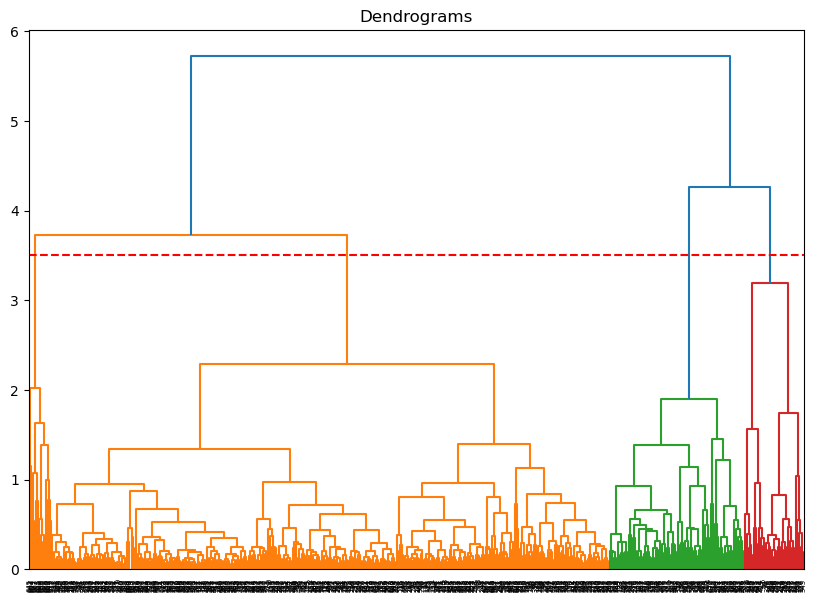

```python
plt.figure(figsize=(10, 7))
plt.title("Dendrograms")
dend_new = shc.dendrogram(shc.linkage(data_scaled1, method='ward'))
plt.axhline(y=3.5, color='r', linestyle='--')
```

n_cluster is set to 4

```python
cluster2 = AgglomerativeClustering(n_clusters=4, affinity='euclidean', linkage='ward')
cluster_ids2 = cluster2.fit_predict(data_scaled1)
```

```python
clustering_data2['cluster2'] = cluster_ids2
clustering_data2.head()
```

|  | Crime type_Anti-social behaviour | Crime type_Bicycle theft | Crime type_Burglary | Crime type_Criminal damage and arson | Crime type_Drugs | Crime type_Other crime | Crime type_Other theft | Crime type_Possession of weapons | Crime type_Public order | Crime type_Robbery | Crime type_Shoplifting | Crime type_Theft from the person | Crime type_Vehicle crime | Crime type_Violence and sexual offences | cluster2 |
| --- | --- | --- | --- | --- | --- | --- | --- | --- | --- | --- | --- | --- | --- | --- | --- |
| 0 | 54 | 9 | 45 | 102 | 30 | 15 | 69 | 36 | 126 | 117 | 78 | 12 | 54 | 441 | 1 |
| 1 | 48 | 0 | 39 | 33 | 21 | 24 | 45 | 18 | 84 | 15 | 0 | 0 | 69 | 321 | 1 |
| 2 | 45 | 3 | 48 | 81 | 54 | 9 | 36 | 21 | 93 | 15 | 30 | 6 | 42 | 387 | 1 |
| 3 | 54 | 6 | 72 | 90 | 30 | 33 | 84 | 36 | 93 | 18 | 27 | 12 | 117 | 615 | 1 |
| 4 | 12 | 0 | 45 | 27 | 6 | 6 | 66 | 15 | 45 | 0 | 18 | 0 | 45 | 153 | 2 |

```python
hiarchical_cluster2 = pd.DataFrame(round(clustering_data2.groupby('cluster2').mean(),1))
hiarchical_cluster2
```

| cluster2 | Crime type_Anti-social behaviour | Crime type_Bicycle theft | Crime type_Burglary | Crime type_Criminal damage and arson | Crime type_Drugs | Crime type_Other crime | Crime type_Other theft | Crime type_Possession of weapons | Crime type_Public order | Crime type_Robbery | Crime type_Shoplifting | Crime type_Theft from the person | Crime type_Vehicle crime | Crime type_Violence and sexual offences |
| --- | --- | --- | --- | --- | --- | --- | --- | --- | --- | --- | --- | --- | --- | --- |
| 0 | 79.6 | 14.0 | 66.9 | 80.7 | 34.6 | 13.8 | 231.1 | 33.1 | 144.8 | 52.7 | 278.8 | 50.2 | 123.0 | 482.6 |
| 1 | 41.8 | 3.5 | 44.7 | 64.2 | 19.9 | 12.9 | 47.0 | 18.3 | 72.6 | 21.9 | 12.3 | 11.6 | 70.6 | 386.9 |
| 2 | 29.7 | 7.0 | 44.1 | 35.3 | 7.6 | 6.2 | 36.1 | 7.8 | 40.4 | 11.6 | 16.5 | 3.5 | 97.5 | 165.6 |
| 3 | 0.0 | 0.2 | 0.2 | 1.0 | 5.4 | 0.9 | 0.6 | 2.1 | 0.8 | 2.2 | 0.0 | 0.0 | 0.3 | 8.0 |